# Lista02_MQ101_CerveraCelia

Celia Cervera Callacná - 21202521058

09/10/2025

# EXERCICIO 1 - Preparação de ambiente

install.packages(c(“tidyverse”, “readr”))

```r
library(tidyverse) #cada vez que inicie R
options(scipen = 999)
```

# EXERCICIO 2 - Base de dados

Verifique: número de linhas/colunas

```r
dados <- readr::read_csv(file.choose()) #atribuir data
glimpse(dados) #mostrar dados horizontal
```

```
## Rows: 10,000
## Columns: 13
## $ id                <chr> "P00001", "P00002", "P00003", "P00004", "P00005", "P…
## $ sexo              <chr> "M", "F", "F", "F", "F", "F", "F", "F", "F", "F", "M…
## $ escolaridade      <chr> "Médio", "Médio", "Médio", "Médio", "Médio", "Médio"…
## $ anos_estudo       <dbl> 10, 9, 9, 10, 11, 11, 10, 8, 15, 11, 6, 7, 5, 4, 10,…
## $ rede_escolar      <chr> "privada", "pública", "pública", "pública", "pública…
## $ municipio         <chr> "Santos", "Dourados", "Várzea Grande", "Curitiba", "…
## $ UF                <chr> "SP", "MS", "MT", "PR", "RJ", "SP", "SC", "SP", "SP"…
## $ idade             <dbl> 39, 30, 31, 44, 26, 51, 47, 48, 25, 53, 23, 27, 35, …
## $ faltas_esc        <dbl> 0, 0, 1, 0, 1, 0, 1, 0, 1, 0, 0, 0, 0, 0, 2, 0, 0, 0…
## $ tempo_estudo_h    <dbl> 2.3, 6.6, 8.8, 4.2, 3.7, 4.9, 0.2, 1.9, 14.4, 3.3, 3…
## $ pressao_sistolica <dbl> 110, 109, 121, 131, 134, 124, 139, 124, 132, 134, 13…
## $ diagnostico       <chr> "sem", "sem", "sem", "sem", "sem", "HAS", "sem", "se…
## $ plano_saude       <chr> "privado", "privado", "nenhum", "nenhum", "SUS", "pr…
```

```r
summary(dados)
```

```
##       id                sexo           escolaridade        anos_estudo
##  Length:10000       Length:10000       Length:10000       Min.   : 4.00
##  Class :character   Class :character   Class :character   1st Qu.: 8.00
##  Mode  :character   Mode  :character   Mode  :character   Median :11.00
##                                                           Mean   :10.74
##                                                           3rd Qu.:13.00
##                                                           Max.   :20.00
##  rede_escolar        municipio              UF                idade
##  Length:10000       Length:10000       Length:10000       Min.   :18.00
##  Class :character   Class :character   Class :character   1st Qu.:31.00
##  Mode  :character   Mode  :character   Mode  :character   Median :40.00
##                                                           Mean   :40.39
##                                                           3rd Qu.:49.00
##                                                           Max.   :80.00
##    faltas_esc     tempo_estudo_h   pressao_sistolica diagnostico
##  Min.   :0.0000   Min.   : 0.000   Min.   : 85.0     Length:10000
##  1st Qu.:0.0000   1st Qu.: 2.800   1st Qu.:112.0     Class :character
##  Median :0.0000   Median : 5.000   Median :122.0     Mode  :character
##  Mean   :0.2346   Mean   : 6.122   Mean   :122.2
##  3rd Qu.:0.0000   3rd Qu.: 8.200   3rd Qu.:131.0
##  Max.   :3.0000   Max.   :34.300   Max.   :175.0
##  plano_saude
##  Length:10000
##  Class :character
##  Mode  :character
##
##
##
```

```r
nrow(dados)#linhas
```

```
## [1] 10000
```

```r
ncol(dados)#colunas
```

```
## [1] 13
```

```r
str(dados)#clases das variaveis
```

```
## spc_tbl_ [10,000 × 13] (S3: spec_tbl_df/tbl_df/tbl/data.frame)
##  $ id               : chr [1:10000] "P00001" "P00002" "P00003" "P00004" ...
##  $ sexo             : chr [1:10000] "M" "F" "F" "F" ...
##  $ escolaridade     : chr [1:10000] "Médio" "Médio" "Médio" "Médio" ...
##  $ anos_estudo      : num [1:10000] 10 9 9 10 11 11 10 8 15 11 ...
##  $ rede_escolar     : chr [1:10000] "privada" "pública" "pública" "pública" ...
##  $ municipio        : chr [1:10000] "Santos" "Dourados" "Várzea Grande" "Curitiba" ...
##  $ UF               : chr [1:10000] "SP" "MS" "MT" "PR" ...
##  $ idade            : num [1:10000] 39 30 31 44 26 51 47 48 25 53 ...
##  $ faltas_esc       : num [1:10000] 0 0 1 0 1 0 1 0 1 0 ...
##  $ tempo_estudo_h   : num [1:10000] 2.3 6.6 8.8 4.2 3.7 4.9 0.2 1.9 14.4 3.3 ...
##  $ pressao_sistolica: num [1:10000] 110 109 121 131 134 124 139 124 132 134 ...
##  $ diagnostico      : chr [1:10000] "sem" "sem" "sem" "sem" ...
##  $ plano_saude      : chr [1:10000] "privado" "privado" "nenhum" "nenhum" ...
##  - attr(*, "spec")=
##   .. cols(
##   ..   id = col_character(),
##   ..   sexo = col_character(),
##   ..   escolaridade = col_character(),
##   ..   anos_estudo = col_double(),
##   ..   rede_escolar = col_character(),
##   ..   municipio = col_character(),
##   ..   UF = col_character(),
##   ..   idade = col_double(),
##   ..   faltas_esc = col_double(),
##   ..   tempo_estudo_h = col_double(),
##   ..   pressao_sistolica = col_double(),
##   ..   diagnostico = col_character(),
##   ..   plano_saude = col_character()
##   .. )
##  - attr(*, "problems")=<externalptr>
```

```r
sum(is.na(dados)) #existencia de NA
```

```
## [1] 0
```

```r
colSums(is.na(dados)) #existencia de NA por colum (ajuda de Gemini)
```

```
##                id              sexo      escolaridade       anos_estudo
##                 0                 0                 0                 0
##      rede_escolar         municipio                UF             idade
##                 0                 0                 0                 0
##        faltas_esc    tempo_estudo_h pressao_sistolica       diagnostico
##                 0                 0                 0                 0
##       plano_saude
##                 0
```

# EXERCICIO 3- Classificação de variaveis

Cria uma tabela (no seu script) indicando o tipo teórico de cada variavel (nominal, ordinal, discreta, continua).

```r
df1 <- data.frame(
  variavel = c("sexo", "escolaridade", "rede_escolar", "idade","faltas_esc",
               "tempo_estudo_h","pressao_sistolica","diagnostico","plano_saude"),
  tipoteorico= c("nominal","ordinal","nominal","continua","discreta","continua",
                  "continua","nominal","nominal"),
  stringsAsFactors = FALSE
)

print(df1)
```

```
##            variavel tipoteorico
## 1              sexo     nominal
## 2      escolaridade     ordinal
## 3      rede_escolar     nominal
## 4             idade    continua
## 5        faltas_esc    discreta
## 6    tempo_estudo_h    continua
## 7 pressao_sistolica    continua
## 8       diagnostico     nominal
## 9       plano_saude     nominal
```

```r
dados <- dados |>
  mutate(sexo= factor(sexo),
         rede_escolar = factor(rede_escolar),
         plano_saude = factor(plano_saude),
         diagnostico = factor(diagnostico),
         escolaridade = factor(escolaridade,
                               levels = c("Fundamental","Médio","Superior"),
                               ordered = TRUE)
   )

str(dados)
```

```
## tibble [10,000 × 13] (S3: tbl_df/tbl/data.frame)
##  $ id               : chr [1:10000] "P00001" "P00002" "P00003" "P00004" ...
##  $ sexo             : Factor w/ 2 levels "F","M": 2 1 1 1 1 1 1 1 1 1 ...
##  $ escolaridade     : Ord.factor w/ 3 levels "Fundamental"<..: 2 2 2 2 2 2 1 1 3 2 ...
##  $ anos_estudo      : num [1:10000] 10 9 9 10 11 11 10 8 15 11 ...
##  $ rede_escolar     : Factor w/ 2 levels "privada","pública": 1 2 2 2 2 2 2 2 2 2 ...
##  $ municipio        : chr [1:10000] "Santos" "Dourados" "Várzea Grande" "Curitiba" ...
##  $ UF               : chr [1:10000] "SP" "MS" "MT" "PR" ...
##  $ idade            : num [1:10000] 39 30 31 44 26 51 47 48 25 53 ...
##  $ faltas_esc       : num [1:10000] 0 0 1 0 1 0 1 0 1 0 ...
##  $ tempo_estudo_h   : num [1:10000] 2.3 6.6 8.8 4.2 3.7 4.9 0.2 1.9 14.4 3.3 ...
##  $ pressao_sistolica: num [1:10000] 110 109 121 131 134 124 139 124 132 134 ...
##  $ diagnostico      : Factor w/ 4 levels "DM","HAS","outros",..: 4 4 4 4 4 2 4 4 4 4 ...
##  $ plano_saude      : Factor w/ 4 levels "ambos","nenhum",..: 3 3 2 2 4 3 4 4 3 2 ...
```

```r
glimpse(dados)
```

```
## Rows: 10,000
## Columns: 13
## $ id                <chr> "P00001", "P00002", "P00003", "P00004", "P00005", "P…
## $ sexo              <fct> M, F, F, F, F, F, F, F, F, F, M, F, F, M, F, F, M, F…
## $ escolaridade      <ord> Médio, Médio, Médio, Médio, Médio, Médio, Fundamenta…
## $ anos_estudo       <dbl> 10, 9, 9, 10, 11, 11, 10, 8, 15, 11, 6, 7, 5, 4, 10,…
## $ rede_escolar      <fct> privada, pública, pública, pública, pública, pública…
## $ municipio         <chr> "Santos", "Dourados", "Várzea Grande", "Curitiba", "…
## $ UF                <chr> "SP", "MS", "MT", "PR", "RJ", "SP", "SC", "SP", "SP"…
## $ idade             <dbl> 39, 30, 31, 44, 26, 51, 47, 48, 25, 53, 23, 27, 35, …
## $ faltas_esc        <dbl> 0, 0, 1, 0, 1, 0, 1, 0, 1, 0, 0, 0, 0, 0, 2, 0, 0, 0…
## $ tempo_estudo_h    <dbl> 2.3, 6.6, 8.8, 4.2, 3.7, 4.9, 0.2, 1.9, 14.4, 3.3, 3…
## $ pressao_sistolica <dbl> 110, 109, 121, 131, 134, 124, 139, 124, 132, 134, 13…
## $ diagnostico       <fct> sem, sem, sem, sem, sem, HAS, sem, sem, sem, sem, HA…
## $ plano_saude       <fct> privado, privado, nenhum, nenhum, SUS, privado, SUS,…
```

# EXERCICIO 4a

```r
tab_plano <- table(dados$plano_saude)
tab_plano
```

```
##
##   ambos  nenhum privado     SUS
##     634    1868    2474    5024
```

```r
prop_plano <- prop.table(tab_plano)
prop_plano
```

```
##
##   ambos  nenhum privado     SUS
##  0.0634  0.1868  0.2474  0.5024
```

```r
cbind(FA = tab_plano, FR = round(100 * prop_plano, 1)) #FA conteo #FR proporciones
```

```
##           FA   FR
## ambos    634  6.3
## nenhum  1868 18.7
## privado 2474 24.7
## SUS     5024 50.2
```

## Interprete: qual categoria é a moda? Qual a proporção dominante?

A moda é SUS e a proporção dominante corresponde tambén á ista categoria.

# EXERCICIO 4b

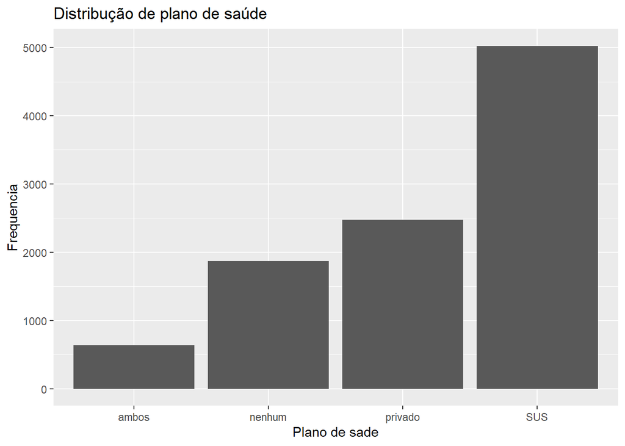

```r
dados |>
  count(plano_saude) |>
  ggplot(aes(x = plano_saude, y = n)) +
  geom_col() +
  labs(x = "Plano de sade", y = "Frequencia",
       title = "Distribução de plano de saúde")
```

# EXERCICIO 4c

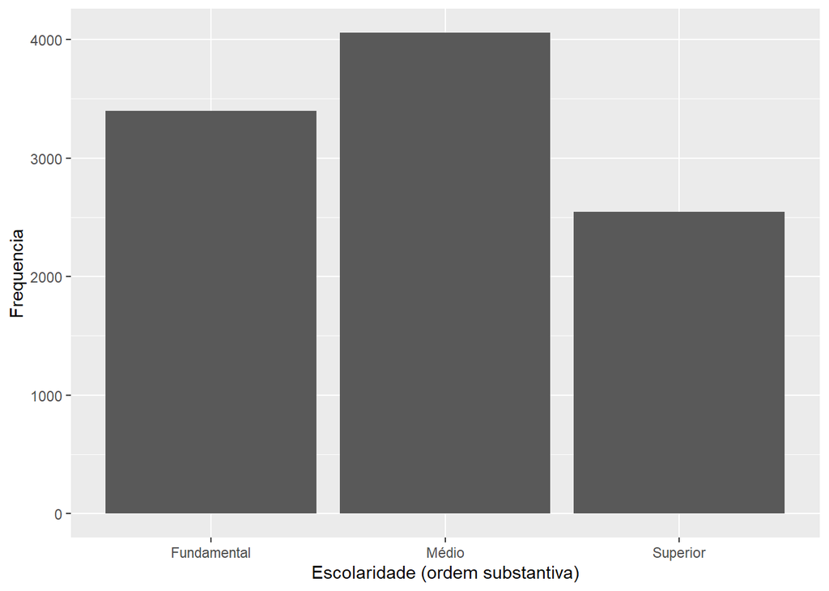

```r
dados |>
  count(escolaridade) |>
  ggplot(aes(x = escolaridade, y = n)) +
  geom_col() +
  labs(x = "Escolaridade (ordem substantiva)", y = "Frequencia")
```

## Explique por qué a ordem importa para interpretar a distribução?

A ordem é importante porque permite visualizar claramente as categorias, tratando-se de uma variável qualitativa ordinal.

# EXERCICIO 5:

Resumen para edade

```r
sumario_idade <- dados |>
  summarise(
    n=sum(!is.na(idade)), #suma todos valore e excluye na
    media=mean(idade,na.rm = TRUE), #excluye NA
    mediana=median(idade,na.rm = TRUE),
    min=min(idade,na.rm = TRUE),
    max=max(idade,na.rm = TRUE),
    dp=sd(idade,na.rm = TRUE)
  )

sumario_idade
```

| n | media | mediana | min | max | dp |
| --- | --- | --- | --- | --- | --- |
| 10000 | 40.3948 | 40 | 18 | 80 | 12.48622 |

Resumen para pressão sistólica

```r
sumario_pressaosistolica <- dados |>
  summarise(
    n=sum(!is.na(pressao_sistolica)), #suma todos valores e excluye na
    media=mean(pressao_sistolica,na.rm = TRUE), #excluye NA
    mediana=median(pressao_sistolica,na.rm = TRUE),
    min=min(pressao_sistolica,na.rm = TRUE),
    max=max(pressao_sistolica,na.rm = TRUE),
    dp=sd(pressao_sistolica,na.rm = TRUE)
  )

sumario_pressaosistolica
```

| n | media | mediana | min | max | dp |
| --- | --- | --- | --- | --- | --- |
| 10000 | 122.1863 | 122 | 85 | 175 | 14.05137 |

## Compare média vs mediana. Há assimetria?

A média (40,4) e a mediana (40) são praticamente iguais. Isso sugere que a #distribuição de idades é bastante simétrica, sem forte inclinação para valores #mais baixos ou mais altos. O mesmo para a pressão sistólica.

Graficar IDADE

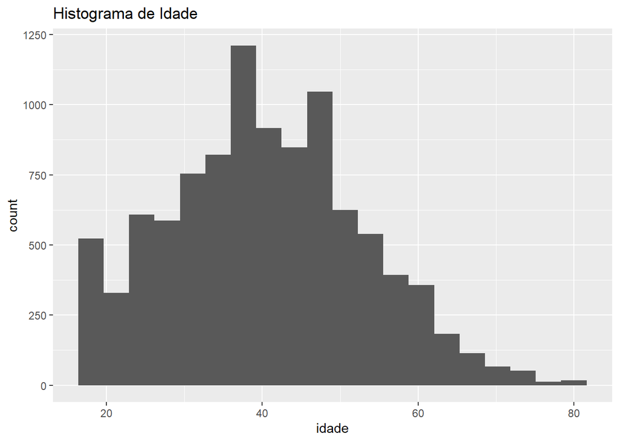

```r
ggplot(dados, aes(x=idade))+
  geom_histogram(bins=20)+
  labs(title = "Histograma de Idade")
```

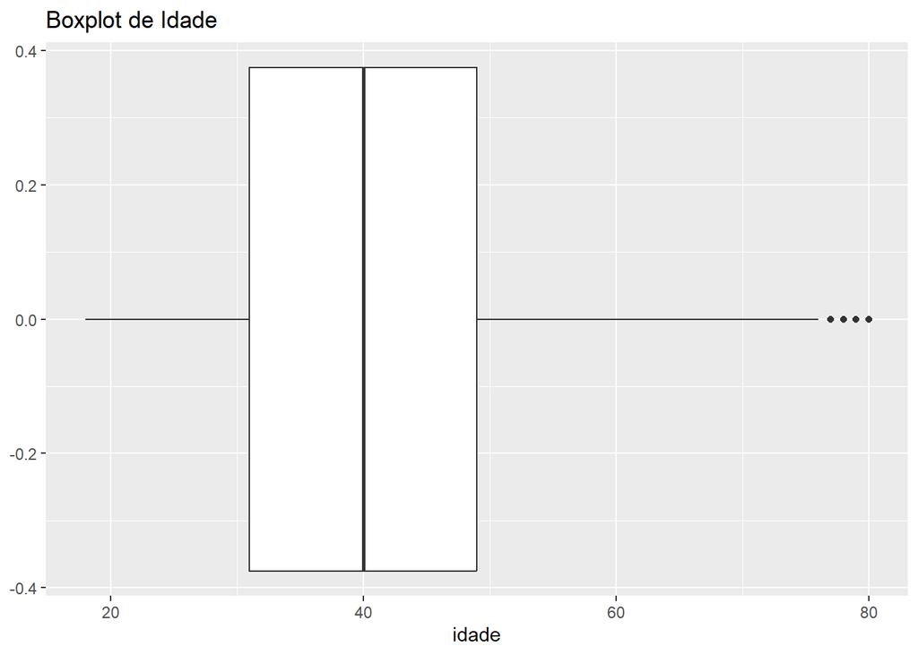

```r
ggplot(dados, aes(x=idade))+
  geom_boxplot()+
  labs(title = "Boxplot de Idade")
```

## Interprete forma, caudas e outliers.

Graficar PRESSÃO SISTÕLICA

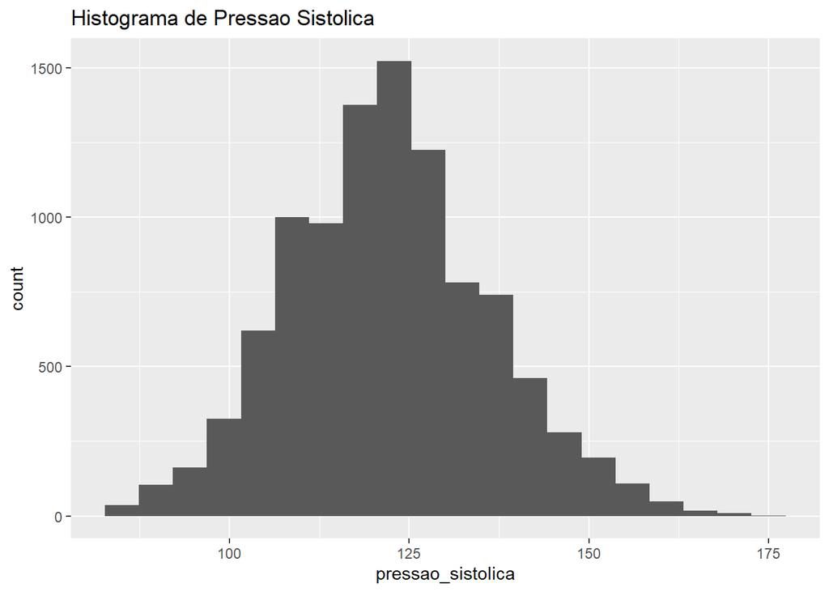

```r
ggplot(dados, aes(x=pressao_sistolica))+
  geom_histogram(bins=20)+
  labs(title = "Histograma de Pressao Sistolica")
```

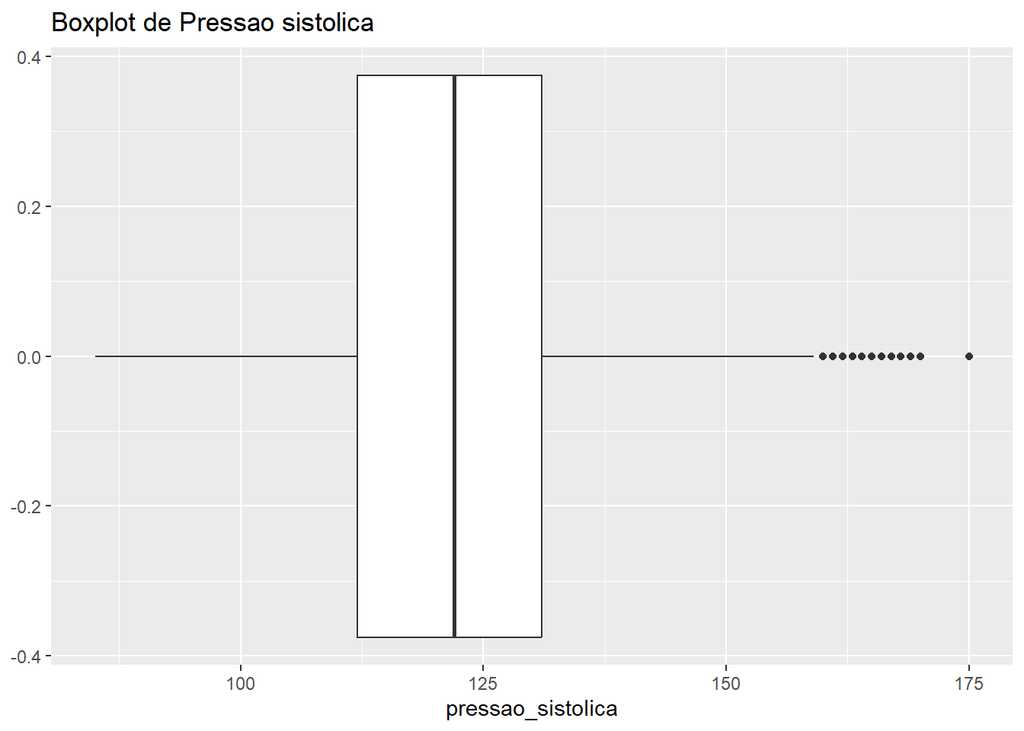

```r
ggplot(dados, aes(x=pressao_sistolica))+
  geom_boxplot()+
  labs(title = "Boxplot de Pressao sistolica")
```

## Interprete forma, caudas e outliers.

Para a variável pressao sistólica, o gráfico mostra uma forma simétrica. Os #valores estão concentrados em torno de 120 mmHg e existem outliers entre #160 mmHg e 175 mmHg.

# EXERCICIO 6: Tabelas cruzadas e resumos por grupo

Cruzando duas qualitativas

```r
tab_cross <- table(dados$diagnostico, dados$plano_saude)
tab_cross
```

```
##
##          ambos nenhum privado  SUS
##   DM         6     21      18   44
##   HAS       77    227     300  626
##   outros    35    112     163  302
##   sem      516   1508    1993 4052
```

```r
round(100 * prop.table(tab_cross, margin = 2), 1) #% por columna
```

```
##
##          ambos nenhum privado  SUS
##   DM       0.9    1.1     0.7  0.9
##   HAS     12.1   12.2    12.1 12.5
##   outros   5.5    6.0     6.6  6.0
##   sem     81.4   80.7    80.6 80.7
```

## Qual diagnóstico mais prevalente dentro de cada tipo de plano?

Em todos os planos de saúde, prevalece o número de pessoas sem diagnóstico.

Resumo de quantitativa por grupo

```r
dados|>
  group_by(sexo)|>
  summarise(
    n=n(),
    media_idade=mean(idade,na.rm=TRUE),
    dp_idade=sd(idade,na.rm=TRUE),
    mediana_idade=median(idade,na.rm = TRUE)
  )
```

| sexo | n | media_idade | dp_idade | mediana_idade |
| --- | --- | --- | --- | --- |
| F | 5192 | 40.30258 | 12.54441 | 40 |
| M | 4808 | 40.49438 | 12.42361 | 40 |

```r
dados|>
  group_by(escolaridade)|>
   summarise(
    n=n(),
    media_idade=mean(idade,na.rm=TRUE),
    dp_idade=sd(idade,na.rm=TRUE),
    mediana_idade=median(idade,na.rm = TRUE)
  )
```

| escolaridade | n | media_idade | dp_idade | mediana_idade |
| --- | --- | --- | --- | --- |
| Fundamental | 3399 | 40.19947 | 12.36561 | 40 |
| Médio | 4056 | 40.53698 | 12.55627 | 40 |
| Superior | 2545 | 40.42908 | 12.53601 | 40 |

## Compare idade por sexo e por escolaridade. Comente diferenças

Entre os participantes, a média de idade das mulheres é de 40,3 anos e a dos #homens é de 40,5 anos. De acordo com o nível de escolaridade, nos três níveis, #a média de idade se mantém em torno dos 40 anos.

# EXERCICIO 7: Valores ausentes e outliers

# 7a valores ausentes

```r
colSums(is.na(dados))
```

```
##                id              sexo      escolaridade       anos_estudo
##                 0                 0                 0                 0
##      rede_escolar         municipio                UF             idade
##                 0                 0                 0                 0
##        faltas_esc    tempo_estudo_h pressao_sistolica       diagnostico
##                 0                 0                 0                 0
##       plano_saude
##                 0
```

# 7b Outliers (regra do IQR)

```r
Q<-quantile(dados$tempo_estudo_h, probs = c(.25, .75), na.rm = TRUE)
Q
```

```
## 25% 75%
## 2.8 8.2
```

```r
IQRv <- IQR(dados$tempo_estudo_h, na.rm = TRUE)
lim_inf <- Q[1]- 1.5 * IQRv
lim_sup <- Q[2] + 1.5 * IQRv

subset_out <- dados |>
  filter(tempo_estudo_h < lim_inf | tempo_estudo_h > lim_sup)

nrow(subset_out)
```

```
## [1] 348
```

```r
head(subset_out)
```

| id | sexo | escolaridade | anos_estudo | rede_escolar | municipio | UF | idade | faltas_esc | tempo_estudo_h | pressao_sistolica | diagnostico | plano_saude |
| --- | --- | --- | --- | --- | --- | --- | --- | --- | --- | --- | --- | --- |
| P00033 | F | Médio | 11 | privada | Blumenau | SC | 63 | 0 | 19.4 | 132 | sem | SUS |
| P00037 | M | Superior | 15 | privada | Pelotas | RS | 44 | 0 | 17.6 | 133 | sem | SUS |
| P00067 | M | Superior | 14 | pública | São Luís | MA | 44 | 0 | 16.9 | 111 | outros | privado |
| P00086 | F | Superior | 18 | privada | Imperatriz | MA | 31 | 1 | 18.0 | 126 | sem | ambos |
| P00095 | F | Superior | 15 | pública | Rio de Janeiro | RJ | 55 | 2 | 21.3 | 136 | HAS | SUS |
| P00183 | M | Superior | 16 | privada | Duque de Caxias | RJ | 37 | 1 | 18.6 | 116 | sem | nenhum |

```r
summary(subset_out$tempo_estudo_h)
```

```
##    Min. 1st Qu.  Median    Mean 3rd Qu.    Max.
##   16.30   17.50   19.05   19.91   21.52   34.30
```

## Discuta: outliers sao erros, casos raros ou informacao valida?

Trata-se de erros, pois são valores que, em média, atingem 19,91 horas, #o que é praticamente impossível em condições normais. Deve-se analisar se eles #devem ser mantidos ou eliminados para não alterar os valores da amostra.

# EXERCICIO 8: Exercícios aplicados (educação e saúde)

## Educação

1. Distribucão de red_escolar (FA/FR)

```r
tab_redescol <- table(dados$rede_escolar)
prop_redescol<- prop.table(tab_redescol)
prop_redescol
```

```
##
## privada pública
##  0.2796  0.7204
```

```r
cbind(FA = tab_redescol, FR = round(100 *prop_redescol, 1)) #FA conteo #FR proporciones
```

```
##           FA FR
## privada 2796 28
## pública 7204 72
```

2. Compare tempo_estudo_h por escolaridade com boxplots.

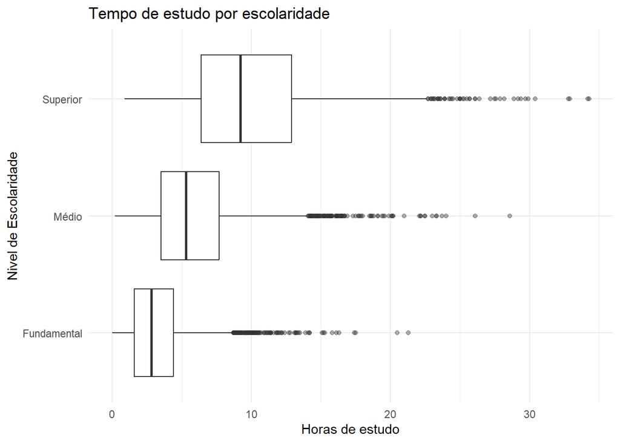

```r
ggplot(dados,aes(tempo_estudo_h,escolaridade))+
  geom_boxplot(show.legend = TRUE, outlier.alpha = 0.4)+
  labs(title = "Tempo de estudo por escolaridade",
       x = "Horas de estudo", y = "Nivel de Escolaridade") +
  theme_minimal()
```

3. Interprete: há padrão monotônico com a ordem da escolaridade?

No gráfico, observa-se que existe um padrão monotônico crescente em relação ao #nível de escolaridade, à medida que se avança no nível, a média de horas de #estudo aumenta.

## Saúde

1. Histograma de pressao_sistolica e reporte média/mediana/DP.”

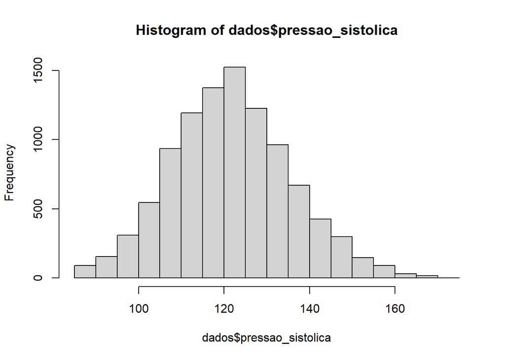

```r
hist(dados$pressao_sistolica)
```

```r
#media:
mean(dados$pressao_sistolica,na.rm = TRUE)
```

```
## [1] 122.1863
```

```r
#mediana
median(dados$pressao_sistolica,na.rm = TRUE)
```

```
## [1] 122
```

```r
#desvio padrão
sd(dados$pressao_sistolica,na.rm = TRUE)
```

```
## [1] 14.05137
```

2. Cruzamento diagnostico × plano_saude (% por coluna).

```r
tab_cross2 <- table(dados$diagnostico, dados$plano_saude)
tab_cross2
```

```
##
##          ambos nenhum privado  SUS
##   DM         6     21      18   44
##   HAS       77    227     300  626
##   outros    35    112     163  302
##   sem      516   1508    1993 4052
```

```r
round(100 * prop.table(tab_cross2, margin = 2), 1) #% por columna
```

```
##
##          ambos nenhum privado  SUS
##   DM       0.9    1.1     0.7  0.9
##   HAS     12.1   12.2    12.1 12.5
##   outros   5.5    6.0     6.6  6.0
##   sem     81.4   80.7    80.6 80.7
```

## Interprete: qual diagnóstico é mais prevalente em cada plano?

Em todos os planos de saúde, prevalece o número de pessoas sem diagnóstico.

# EXERCICIO 9: Desafio (opcional)

## Crie uma tabela-síntese por escolaridade com: n, média e mediana de idade, DP, mínimo e máximo;

```r
dados|>
  group_by(escolaridade)|>
  summarise(
    n=n(),
    media_idade=mean(idade,na.rm=TRUE),
    mediana_idade=median(idade,na.rm = TRUE),
    dp_idade=sd(idade,na.rm=TRUE),
    minimo=min(idade,na.rm=TRUE),
    maximo=max(idade,na.rm=TRUE)
  )
```

| escolaridade | n | media_idade | mediana_idade | dp_idade | minimo | maximo |
| --- | --- | --- | --- | --- | --- | --- |
| Fundamental | 3399 | 40.19947 | 40 | 12.36561 | 18 | 80 |
| Médio | 4056 | 40.53698 | 40 | 12.55627 | 18 | 80 |
| Superior | 2545 | 40.42908 | 40 | 12.53601 | 18 | 80 |

## FA/FR de plano_saude dentro de cada escolaridade.

```r
T1 <- table(dados$plano_saude, dados$escolaridade)
prop_T1 <- prop.table(T1)

cbind(FA=T1,FR=round(prop_T1*100,1))
```

```
##         Fundamental Médio Superior Fundamental Médio Superior
## ambos           105   260      269         1.0   2.6      2.7
## nenhum          857   719      292         8.6   7.2      2.9
## privado         415   975     1084         4.2   9.8     10.8
## SUS            2022  2102      900        20.2  21.0      9.0
```

## Produza dois gráficos

1. Barras empilhadas de plano_saude por escolaridade (proporções).

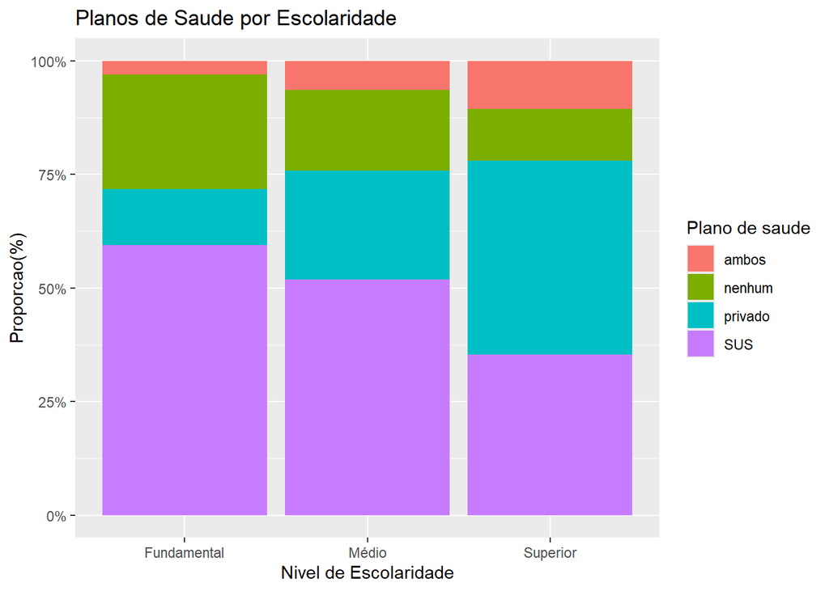

```r
p_barras_proporciones <- dados |>
  group_by(escolaridade) |>
  mutate(proportion= n()/sum(n()))|>
  ungroup() |>
  ggplot(aes(x =escolaridade, y= proportion, fill = plano_saude)) +
  geom_col(position = "fill")+
  scale_y_continuous(labels = scales::percent) +
  labs(
    title = "Planos de Saude por Escolaridade",
    x = "Nivel de Escolaridade",
    y = "Proporcao(%)",
    fill = "Plano de saude")

  print(p_barras_proporciones)
```

2. Boxplot de tempo_estudo_h por escolaridade

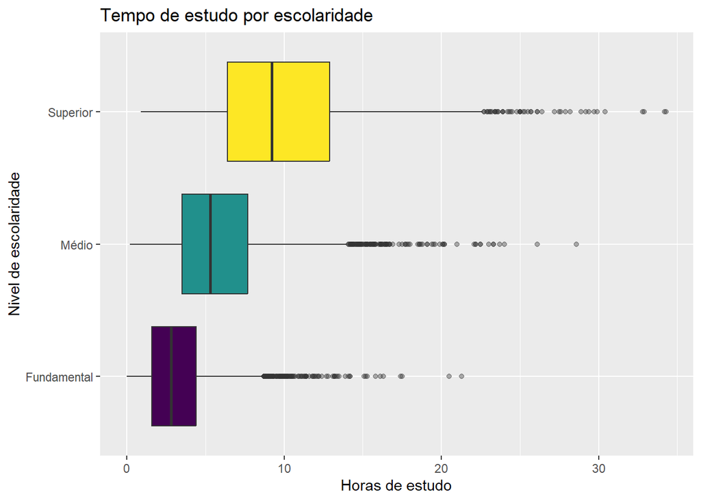

```r
 graf_tempo <- dados |>
    group_by(escolaridade) |>
    ungroup() |>
    ggplot(aes(x=escolaridade, y=tempo_estudo_h, fill=escolaridade))+
    geom_boxplot(show.legend = FALSE, outlier.alpha = 0.4)+
    coord_flip()+
    labs(title= "Tempo de estudo por escolaridade",
    x="Nivel de escolaridade",
    y="Horas de estudo")

  print(graf_tempo)
```